# Aggregation example

November, 2020

Replication code for empirical example in the Appendix of “How do populations aggregate?” by Dennis M. Feehan and Elizabeth Wrigley-Field

NOTE: in order to run this code, you will have to download the life tables from the [United States Mortality Database](https://usa.mortality.org/). This requires that you register (which is free).

The file you need is the [bundled archive called lifetables.zip](https://usa.mortality.org/uploads/lifetables/lifetables.zip).

This analysis is based on the version of `lifetables.zip` that was downloaded from the USMD website on March 21, 2019.

```r
library(tidyverse)
library(HMDHFDplus)
library(patchwork)
library(here)
```

Create directories for data and output

```r
dir.create(here("raw-data"), showWarnings=FALSE)
dir.create(here("out"), showWarnings=FALSE)

# this should be whichever directory has the raw USMD data
usmd.data.dir <- here("raw-data")

# this is where we'll save outputs
out.dir <- here("out")
```

This chunk will ask you for your US Mortality Database username and password. Then it will download the lifetables for you.

```r
usmd_uname <- readline("Your username:")
feehan@berkeley.edu
usmd_pwd <- readline("Your password:")
trixie

httr::GET(url = "https://usa.mortality.org/uploads/lifetables/lifetables.zip",
          httr::authenticate(password=usmd_pwd, user=usmd_uname),
          httr::write_disk(file.path(usmd.data.dir, 'lifetables.zip')))
```

```
Response [https://usa.mortality.org/uploads/lifetables/lifetables.zip]
  Date: 2020-12-05 02:52
  Status: 200
  Content-Type: application/zip
  Size: 93.5 MB
<ON DISK>  /home/rstudio/aggregation-code-release/raw-data/lifetables.zip
```

Load the data

```r
zipped_csv_names <- grep('\\.csv$', unzip(file.path(usmd.data.dir, 'lifetables.zip'), list=TRUE)$Name,
                           ignore.case=TRUE, value=TRUE)

state_codes <- c("AK", "AL", "AR", "AZ", "CA", "CO", "CT", #"DC",
                 "DE", "FL",
"GA", "HI", "IA", "ID", "IL", "IN", "KS", "KY", "LA", "MA", "MD",
"ME", "MI", "MN", "MO", "MS", "MT", "NC", "ND", "NE", "NH", "NJ",
"NM", "NV", "NY", "OH", "OK", "OR", "PA", "RI", "SC", "SD", "TN",
"TX", "UT", "VA", "VT", "WA", "WI", "WV", "WY")
```

```r
for (sc in state_codes) {
  cat(glue::glue("state code is {sc}\n"))
  get_lt(sc, 'b')
}
```

```
state code is AKstate code is ALstate code is ARstate code is AZstate code is CAstate code is COstate code is CTstate code is DEstate code is FLstate code is GAstate code is HIstate code is IAstate code is IDstate code is ILstate code is INstate code is KSstate code is KYstate code is LAstate code i…
```

```r
# quick function to get the life table for a state
get_lt <- function(code, type='b', fmt="1x1", zipfn = file.path('raw-data', 'lifetables.zip')) {
  fullpath <- glue::glue("lifetables/States/{code}/{code}_{type}ltper_{fmt}.csv")
  this_lt <- read_csv(unz(zipfn, fullpath),
                      col_types='ccdcdddddddd') %>%
             mutate(Age = HMDHFDplus::age2int(Age))
  return(this_lt)
}

# read all the lifetables in
lts_both <- setNames(map(state_codes, ~get_lt(.x, 'b')), state_codes)
lts_male <- setNames(map(state_codes, ~get_lt(.x, 'm')), state_codes)
lts_female <- setNames(map(state_codes, ~get_lt(.x, 'f')), state_codes)

lts <- bind_rows(bind_rows(lts_both), bind_rows(lts_male), bind_rows(lts_female))

# save this to avoid having to re-load the data all the time
# (this is not necessary for replication, so commenting it out)
#write_csv(lts, file=file.path(out.dir, 'usmd_lts.csv'))
```

```r
# weighted harmonic mean of x, weights given by w
hmean <- function(x, w) {
  w.o.x <- w/x
  return(sum(w) / sum(w.o.x))
}
```

In these life tables, mx is not exactly equal to dx / Lx. We’ll add a column that is.

```r
lts <- lts %>% mutate(dx.over.Lx = dx/Lx)
```

Go through and calculate reldiff by age and sex when aggregation is incorrect

```r
reldiffs <- lts %>%
  filter(Year == 2015) %>%
  split(list(.$Sex, .$Age)) %>%
  map_df(function(asdat) {

    ## only look at states with at least 1 death
    asdat <- asdat %>% filter(dx > 0)

    direct.agg.mx <- sum(asdat$dx) / sum(asdat$Lx)

    # harmonic mean of rates, weighted by deaths (correct)
    hm.mx.d <- hmean(asdat$dx.over.Lx, asdat$dx)
    # arithmetic mean of rates, weighted by nLx (correct)
    am.mx.L <- weighted.mean(asdat$dx.over.Lx, asdat$Lx)

    # arithmetic mean of rates, weighted by deaths (incorrect)
    am.mx <- weighted.mean(asdat$dx.over.Lx, asdat$dx)
    # arithmetic mean of rates, unweighted (incorrect)
    uam.mx <- mean(asdat$dx.over.Lx)

    # arithmetic mean of death rates, weighted by exposure, squared
    am.m.d2 <- weighted.mean(asdat$dx.over.Lx, asdat$Lx)^2
    # arithmetic mean of squared death rates, weighted by exposure
    am.m2.d <- weighted.mean(asdat$dx.over.Lx^2, asdat$Lx)

    # appropriately weighted cv2.mx
    w.cv2.mx <- (am.m2.d/am.m.d2) - 1

    # the weighted cv (not squared)
    w.cv.mx <- sqrt(w.cv2.mx)

    # diff in arithmetic mean weighted by deaths, relative to true aggregate value
    reldiff <- (am.mx - direct.agg.mx) / direct.agg.mx

    # diff in unweighted arithmetic mean, relative to true aggregate value
    reldiff2 <- (uam.mx - direct.agg.mx) / direct.agg.mx

    return(tibble(age=asdat$Age[1],
                  sex=asdat$Sex[1],
                  n=nrow(asdat),
                  direct=direct.agg.mx,
                  # correct harmonic mean
                  hm=hm.mx.d,
                  # arithmetic mean with wrong weights
                  am=am.mx,
                  # arithmetic mean with no weights
                  uam=uam.mx,
                  reldiff.am = reldiff,
                  reldiff.uam = reldiff2,
                  w.cv.mx = w.cv.mx,
                  w.cv2.mx = w.cv2.mx))
  }) %>%
  mutate(sex = dplyr::recode(sex,
                             'b'='Both sexes',
                             'm'='Males',
                             'f'='Females'))
```

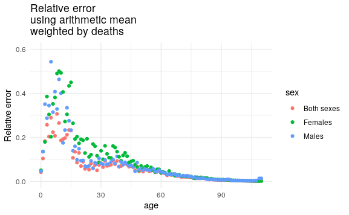

```r
fig.h <- 5
fig.w <- 8

am.reldiffs <- ggplot(reldiffs) +
  geom_point(aes(x=age, y=reldiff.am, color=sex)) +
  expand_limits(y=c(0,.6)) +
  theme_minimal() +
  ylab("Relative error") +
  ggtitle("Relative error\nusing arithmetic mean\nweighted by deaths")
#ggsave(plot=am.reldiffs, filename='am-reldiffs.pdf', height=fig.h, width=fig.w)
am.reldiffs
```

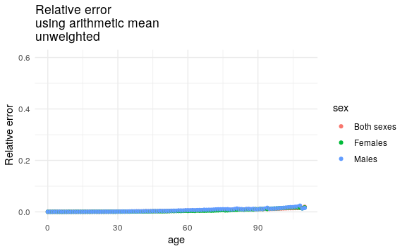

```r
uam.reldiffs <- ggplot(reldiffs) +
  geom_point(aes(x=age, y=reldiff.uam, color=sex)) +
  expand_limits(y=c(0,.6)) +
  theme_minimal() +
  ylab("Relative error") +
  ggtitle("Relative error\nusing arithmetic mean\nunweighted")
#ggsave(plot=uam.reldiffs, filename='uam-reldiffs.pdf', height=fig.h, width=fig.w)
uam.reldiffs
```

```r
fig.h <- 5
fig.w <- 8

relerr.plot <- (uam.reldiffs | am.reldiffs) + plot_annotation(tag_levels = 'A')
ggsave(plot=relerr.plot, filename=file.path(out.dir, 'relerrs.pdf'), height=fig.h, width=fig.w)
```

Plot the actual aggregate death rates

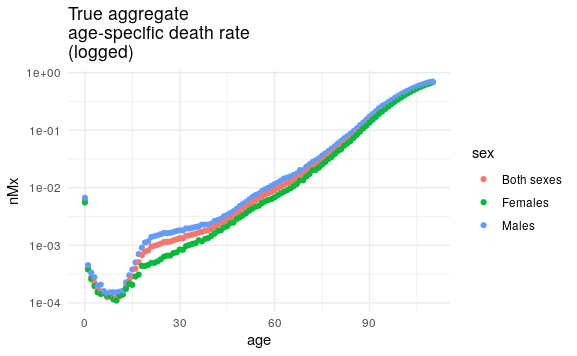

```r
agg.pseudous <- ggplot(reldiffs) +
  geom_point(aes(x=age, y=direct, color=sex)) +
  theme_minimal() +
  scale_y_log10() +
  ylab("nMx") +
  ggtitle("True aggregate\nage-specific death rate\n(logged)")
#ggsave(plot=agg.pseudous, filename='agg-pseudo-us.pdf', height=fig.h, width=fig.w)
agg.pseudous
```

Plot the variance in means

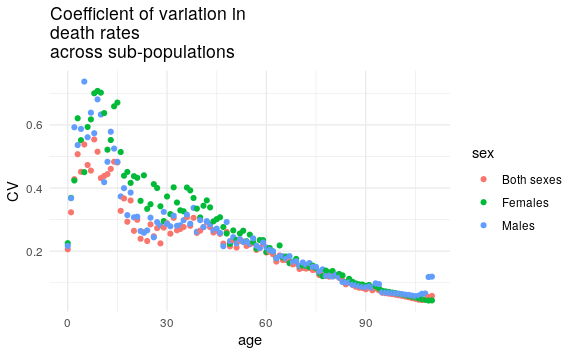

```r
cv.pseudous <- ggplot(reldiffs) +
  geom_point(aes(x=age, y=w.cv.mx, color=sex)) +
  theme_minimal() +
  ylab("CV") +
  ggtitle("Coefficient of variation in\ndeath rates\nacross sub-populations")

cv.pseudous
```

```r
fig.h <- 5
fig.w <- 8

pseudo.m.plot <- (agg.pseudous | cv.pseudous) + plot_annotation(tag_levels = 'A')
ggsave(plot=pseudo.m.plot, filename=file.path(out.dir, 'pseudous-m.pdf'), height=fig.h, width=fig.w)
```

Directly compare rel-sd and error in second strategy

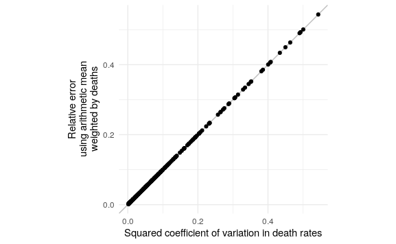

```r
cv2.relerr.plot <- ggplot(reldiffs) +
  #geom_point(aes(x=w.cv2.mx, y=reldiff.am, color=log(direct))) +
  geom_abline(intercept=0, slope=1, color='grey') +
  geom_point(aes(x=w.cv2.mx, y=reldiff.am)) +
  #xlim(0,.1) + ylim(0,.1) +
  xlab("Squared coefficient of variation in death rates") +
  ylab("Relative error\nusing arithmetic mean\nweighted by deaths") +
  theme_minimal() +
  coord_equal()

cv2.relerr.plot
```

```r
fig.h <- 5
fig.w <- 5

ggsave(plot=cv2.relerr.plot,
       filename=file.path(out.dir, 'cv2-relerr.pdf'), height=fig.h, width=fig.w)
```